# Concrete Strength Prediction

## Multivariate Analysis

Correlation to find relationship between different variables

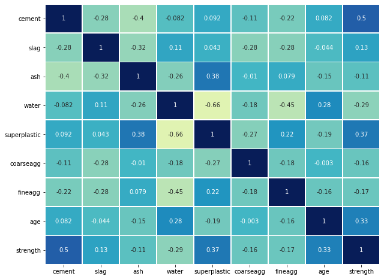

```python
plt.figure(figsize=(10,8))
sns.heatmap(concrete_df.corr(),
            annot=True,
            linewidths=.7,
            center=0,
            cbar=False,
            cmap="YlGnBu")
plt.show()
```

## Observations:

High +ve correlation between cement and strength is observed , age and superplastic also affects concrete strength in higher degree

High -ve correlation between superplastic and water - these may be independent of each other

Little +ve correlation shown between superplastic and ash / fineagg

Apart from these , there is no strong correlation between variables

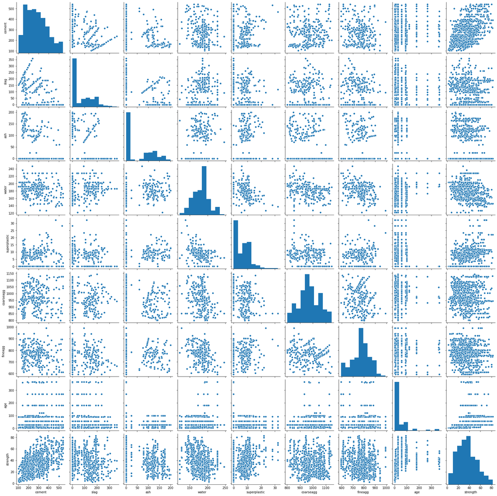

```python
sns.pairplot(concrete_df, palette="husl")
```

Above plot shows visual representation of correlation between different variables

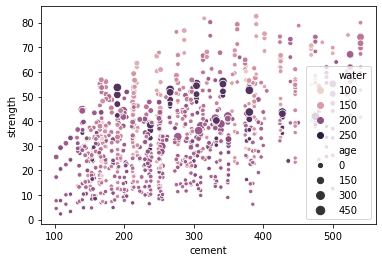

```python
sns.scatterplot(x='cement',y='strength',size='age',hue='water',data=concrete_df)
plt.show()
```

Strength increases as amount of cement increases as dots are moving up when moving towards x axis

Strength increases with age

Higher the age more the water required

Strength increases when water is less - y axis dots color are losing its darkness when moving upwards

## Feature Engineering

Water Cement ratio and fine/coarse aggregate ratio aids as an important factor in determining concrete strength

```python
water_cement=concrete_df.water/concrete_df.cement
aggregate_ratio=concrete_df.fineagg/concrete_df.coarseagg
```

```python
water_cement # water_cement ratio
```

```
0       1.440198
1       0.937241
2       0.749600
3       0.857143
4       1.248708
          ...
1025    1.333333
1026    0.266893
1027    0.649783
1028    0.666667
1029    0.320370
Length: 1030, dtype: float64
```

```python
aggregate_ratio
```

```
0       0.770220
1       0.736677
2       0.899990
3       0.718884
4       0.665171
          ...
1025    0.837669
1026    1.048821
1027    0.883002
1028    0.718884
1029    0.544889
Length: 1030, dtype: float64
```

```python
Water_Cement=pd.DataFrame({'Water_Cementratio':water_cement.values})
Aggregate_Ratio=pd.DataFrame({'Agg_ratio':aggregate_ratio.values})
```

```python
concrete_df=pd.concat([concrete_df,Water_Cement],axis=1)
concrete_df=pd.concat([concrete_df,Aggregate_Ratio],axis=1)
```

```python
concrete_df.head(10) # new dataframe with extracted values
```

|  | cement | slag | ash | water | superplastic | coarseagg | fineagg | age | strength | Water_Cementratio | Agg_ratio |
| --- | --- | --- | --- | --- | --- | --- | --- | --- | --- | --- | --- |
| 0 | 141.3 | 212.0 | 0.0 | 203.5 | 0.0 | 971.8 | 748.5 | 28 | 29.89 | 1.440198 | 0.770220 |
| 1 | 168.9 | 42.2 | 124.3 | 158.3 | 10.8 | 1080.8 | 796.2 | 14 | 23.51 | 0.937241 | 0.736677 |
| 2 | 250.0 | 0.0 | 95.7 | 187.4 | 5.5 | 956.9 | 861.2 | 28 | 29.22 | 0.749600 | 0.899990 |
| 3 | 266.0 | 114.0 | 0.0 | 228.0 | 0.0 | 932.0 | 670.0 | 28 | 45.85 | 0.857143 | 0.718884 |
| 4 | 154.8 | 183.4 | 0.0 | 193.3 | 9.1 | 1047.4 | 696.7 | 28 | 18.29 | 1.248708 | 0.665171 |
| 5 | 255.0 | 0.0 | 0.0 | 192.0 | 0.0 | 889.8 | 945.0 | 90 | 21.86 | 0.752941 | 1.062036 |
| 6 | 166.8 | 250.2 | 0.0 | 203.5 | 0.0 | 975.6 | 692.6 | 7 | 15.75 | 1.220024 | 0.709922 |
| 7 | 251.4 | 0.0 | 118.3 | 188.5 | 6.4 | 1028.4 | 757.7 | 56 | 36.64 | 0.749801 | 0.736776 |
| 8 | 296.0 | 0.0 | 0.0 | 192.0 | 0.0 | 1085.0 | 765.0 | 28 | 21.65 | 0.648649 | 0.705069 |
| 9 | 155.0 | 184.0 | 143.0 | 194.0 | 9.0 | 880.0 | 699.0 | 28 | 28.99 | 1.251613 | 0.794318 |

```python
#Here we are going to use StandardScaler to scale our data.
from sklearn.preprocessing import StandardScaler

scaler = StandardScaler()
#What all columns to scale? I have preferred all columns except onehotencoded columns and target columns as
#scaling of target feature will not change anything as they already have values like 0 and 1 only.
#You may only scale numerical features and leave categorical features as required according to business problem need and results.
cols_to_scale = ['cement', 'slag','ash','water','superplastic','coarseagg','fineagg','age','strength','Water_Cementratio','Agg_ratio']

concrete_df[cols_to_scale] = scaler.fit_transform(concrete_df[cols_to_scale].to_numpy())
```

```python
concrete_df.describe()
```

|  | cement | slag | ash | water | superplastic | coarseagg | fineagg | age | strength | Water_Cementratio | Agg_ratio |
| --- | --- | --- | --- | --- | --- | --- | --- | --- | --- | --- | --- |
| count | 1.030000e+03 | 1.030000e+03 | 1.030000e+03 | 1.030000e+03 | 1.030000e+03 | 1.030000e+03 | 1.030000e+03 | 1.030000e+03 | 1.030000e+03 | 1.030000e+03 | 1.030000e+03 |
| mean | -3.858833e-16 | 9.593189e-18 | 3.634633e-16 | -2.014570e-16 | 1.103756e-16 | 7.116206e-16 | 9.537139e-16 | 3.794160e-17 | -3.729487e-17 | -7.394301e-17 | -1.271906e-16 |
| std | 1.000486e+00 | 1.000486e+00 | 1.000486e+00 | 1.000486e+00 | 1.000486e+00 | 1.000486e+00 | 1.000486e+00 | 1.000486e+00 | 1.000486e+00 | 1.000486e+00 | 1.000486e+00 |
| min | -1.715253e+00 | -8.568879e-01 | -8.471439e-01 | -2.800211e+00 | -1.039143e+00 | -2.212138e+00 | -2.240917e+00 | -7.073594e-01 | -2.005552e+00 | -1.533755e+00 | -2.331307e+00 |
| 25% | -8.500535e-01 | -8.568879e-01 | -8.471439e-01 | -7.808939e-01 | -1.039143e+00 | -5.265174e-01 | -5.319697e-01 | -6.123314e-01 | -7.251305e-01 | -6.848203e-01 | -5.665998e-01 |
| 50% | -7.915193e-02 | -6.017783e-01 | -8.471439e-01 | 1.608294e-01 | 3.271508e-02 | -6.329352e-02 | 7.386739e-02 | -2.797331e-01 | -8.222491e-02 | -2.323301e-01 | -1.008569e-01 |
| 75% | 6.589606e-01 | 8.007446e-01 | 1.002278e+00 | 4.887927e-01 | 6.691307e-01 | 7.267605e-01 | 6.291661e-01 | 1.637312e-01 | 6.178744e-01 | 5.954971e-01 | 7.845675e-01 |
| max | 2.477915e+00 | 3.310675e+00 | 2.281084e+00 | 3.065647e+00 | 4.353642e+00 | 2.214224e+00 | 2.733062e+00 | 5.057677e+00 | 2.801717e+00 | 3.613432e+00 | 3.160483e+00 |

```python
concrete_df.head()
```

|  | cement | slag | ash | water | superplastic | coarseagg | fineagg | age | strength | Water_Cementratio | Agg_ratio |
| --- | --- | --- | --- | --- | --- | --- | --- | --- | --- | --- | --- |
| 0 | -1.339017 | 1.601441 | -0.847144 | 1.027590 | -1.039143 | -0.014398 | -0.312970 | -0.279733 | -0.355018 | 2.204637 | -0.271605 |
| 1 | -1.074790 | -0.367541 | 1.096078 | -1.090116 | 0.769617 | 1.388141 | 0.282260 | -0.501465 | -0.737108 | 0.602112 | -0.563307 |
| 2 | -0.298384 | -0.856888 | 0.648965 | 0.273274 | -0.118015 | -0.206121 | 1.093371 | -0.279733 | -0.395144 | 0.004250 | 0.856891 |
| 3 | -0.145209 | 0.465044 | -0.847144 | 2.175461 | -1.039143 | -0.526517 | -1.292542 | -0.279733 | 0.600806 | 0.346903 | -0.718032 |
| 4 | -1.209776 | 1.269798 | -0.847144 | 0.549700 | 0.484905 | 0.958372 | -0.959363 | -0.279733 | -1.049727 | 1.594510 | -1.185132 |

```python
corr=concrete_df.corr()
```

```python
##corr
```

```python
## Prepare y variable - round off values of strength
concrete_df['strength']=concrete_df['strength'].round()
```

```python
concrete_df['strength']
```

```
0      -0.0
1      -1.0
2      -0.0
3       1.0
4      -1.0
       ...
1025   -1.0
1026    0.0
1027    1.0
1028    1.0
1029    1.0
Name: strength, Length: 1030, dtype: float64
```

```python
concrete_df['strength'].value_counts() # value count on y - variable
```

```
-0.0    391
-1.0    298
 1.0    202
 2.0     78
-2.0     51
 3.0     10
Name: strength, dtype: int64
```

```python
## Combine negative values to 0 and positive values to 1
concrete_df['strength']=concrete_df['strength'].replace(-0.0,0)
concrete_df['strength']=concrete_df['strength'].replace(-1.0,0)
concrete_df['strength']=concrete_df['strength'].replace(-2.0,0)
concrete_df['strength']=concrete_df['strength'].replace(1.0,1)
concrete_df['strength']=concrete_df['strength'].replace(2.0,1)
concrete_df['strength']=concrete_df['strength'].replace(3.0,1)
```

```python
concrete_df.head()
```

|  | cement | slag | ash | water | superplastic | coarseagg | fineagg | age | strength | Water_Cementratio | Agg_ratio |
| --- | --- | --- | --- | --- | --- | --- | --- | --- | --- | --- | --- |
| 0 | -1.339017 | 1.601441 | -0.847144 | 1.027590 | -1.039143 | -0.014398 | -0.312970 | -0.279733 | 0.0 | 2.204637 | -0.271605 |
| 1 | -1.074790 | -0.367541 | 1.096078 | -1.090116 | 0.769617 | 1.388141 | 0.282260 | -0.501465 | 0.0 | 0.602112 | -0.563307 |
| 2 | -0.298384 | -0.856888 | 0.648965 | 0.273274 | -0.118015 | -0.206121 | 1.093371 | -0.279733 | 0.0 | 0.004250 | 0.856891 |
| 3 | -0.145209 | 0.465044 | -0.847144 | 2.175461 | -1.039143 | -0.526517 | -1.292542 | -0.279733 | 1.0 | 0.346903 | -0.718032 |
| 4 | -1.209776 | 1.269798 | -0.847144 | 0.549700 | 0.484905 | 0.958372 | -0.959363 | -0.279733 | 0.0 | 1.594510 | -1.185132 |

## Data Preparation

```python
X = concrete_df.drop('strength', axis=1)
y = concrete_df[['strength']]

#X=X.values
#y=y.values

print(X.head())
print(y.head())
```

```
     cement      slag       ash     water  superplastic  coarseagg   fineagg  \
0 -1.339017  1.601441 -0.847144  1.027590     -1.039143  -0.014398 -0.312970
1 -1.074790 -0.367541  1.096078 -1.090116      0.769617   1.388141  0.282260
2 -0.298384 -0.856888  0.648965  0.273274     -0.118015  -0.206121  1.093371
3 -0.145209  0.465044 -0.847144  2.175461     -1.039143  -0.526517 -1.292542
4 -1.209776  1.269798 -0.847144  0.549700      0.484905   0.958372 -0.959363

        age  Water_Cementratio  Agg_ratio
0 -0.279733           2.204637  -0.271605
1 -0.501465           0.602112  -0.563307
2 -0.279733           0.004250   0.856891
3 -0.279733           0.346903  -0.718032
4 -0.279733           1.594510  -1.185132
   strength
0       0.0
1       0.0
2       0.0
3       1.0
4       0.0
```

```python
print(X.shape)
print(y.shape)
print(y.dtypes)
```

```
(1030, 10)
(1030, 1)
strength    float64
dtype: object
```

```python
#split the data into train and test
from sklearn.model_selection import train_test_split
X_train, X_test, y_train, y_test = train_test_split(X, y, test_size=0.3, random_state=42)
```

## Choose Model , Train and Evaluate

```python
from sklearn.linear_model import LinearRegression
linearregression = LinearRegression()
linearregression.fit(X_train, y_train)

print("Intercept of the linear equation:", linearregression.intercept_)
print("\nCOefficients of the equation are:", linearregression.coef_)

from sklearn.metrics import mean_absolute_error, mean_squared_error, r2_score

pred = linearregression.predict(X_test)
```

```
Intercept of the linear equation: [0.28960192]

COefficients of the equation are: [[ 0.23727943  0.18346496  0.09549745 -0.1042212   0.03753629  0.16547073
  -0.13289827  0.15645642 -0.00100603  0.23714581]]
```

```python
# Mean Absolute Error
mean_absolute_error(y_test, pred)
```

```
0.2779417568502793
```

```python
# RMSE
mean_squared_error(y_test, pred)**0.5
```

```
0.3600447946283292
```

```python
# R2 Squared:
r2_score(y_test, pred)
```

```
0.32979113832349805
```

```python
# Training Score
linearregression.score(X_train, y_train)
```

```
0.3952327193448808
```

```python
# Testing score
linearregression.score(X_test, y_test)
```

```
0.32979113832349805
```

Linear Regression gives a R2 value of 0.32 which is not a very good score

Testing and training score is also around 30~40 approximately

Hence overall model is not so satisfactory , we need a higher degree

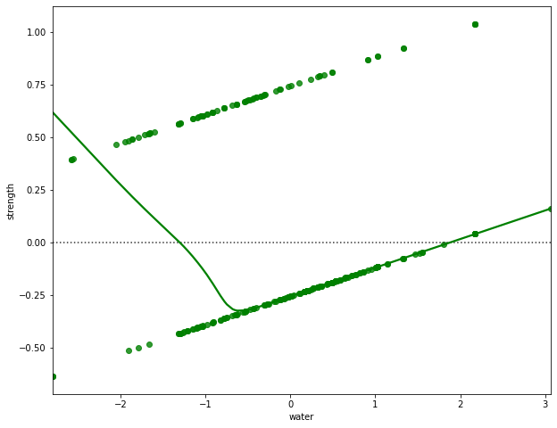

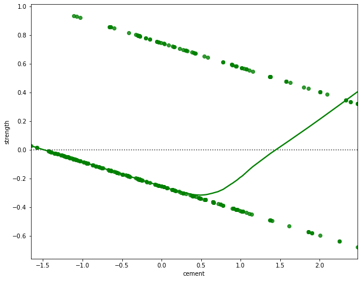

```python
fig = plt.figure(figsize=(10,8))
sns.residplot(x= X_test['water'], y= y_test['strength'], color='green', lowess=True )


fig = plt.figure(figsize=(10,8))
sns.residplot(x= X_test['cement'], y= y_test['strength'], color='green', lowess=True )
```

Lets use stats model to use adjusted R2

```python
data_train = pd.concat([X_train, y_train], axis=1)
data_train.head()
```

|  | cement | slag | ash | water | superplastic | coarseagg | fineagg | age | Water_Cementratio | Agg_ratio | strength |
| --- | --- | --- | --- | --- | --- | --- | --- | --- | --- | --- | --- |
| 196 | -0.472620 | -0.856888 | 1.053868 | -0.354542 | 0.082958 | 1.074178 | 0.061389 | -0.501465 | 0.007586 | -0.561044 | 0.0 |
| 631 | 1.578011 | -0.578587 | 0.387889 | -0.916764 | 0.903600 | -0.076161 | -0.768440 | -0.675683 | -1.226808 | -0.566600 | 0.0 |
| 81 | -1.581225 | 1.149201 | -0.847144 | 0.488793 | -1.039143 | -0.812172 | 1.476465 | 0.702224 | 2.889589 | 1.555505 | 0.0 |
| 526 | 2.094977 | -0.856888 | -0.847144 | 0.863608 | -1.039143 | 1.956877 | -2.003823 | -0.675683 | -1.109648 | -2.231125 | 0.0 |
| 830 | 1.376969 | 0.375755 | -0.847144 | -1.315006 | 1.724241 | -1.554617 | 1.416567 | -0.612331 | -1.233347 | 2.083794 | 1.0 |

```python
import statsmodels.formula.api as smf
lm1 = smf.ols(formula= 'strength ~ cement+slag+ash+water+superplastic+coarseagg+fineagg+age+Water_Cementratio+Agg_ratio', data = data_train).fit()
lm1.params
```

```
Intercept            0.289602
cement               0.237279
slag                 0.183465
ash                  0.095497
water               -0.104221
superplastic         0.037536
coarseagg            0.165471
fineagg             -0.132898
age                  0.156456
Water_Cementratio   -0.001006
Agg_ratio            0.237146
dtype: float64
```

```python
print(lm1.summary())  #Inferential statistics
```

```
                            OLS Regression Results
==============================================================================
Dep. Variable:               strength   R-squared:                       0.395
Model:                            OLS   Adj. R-squared:                  0.387
Method:                 Least Squares   F-statistic:                     46.40
Date:                Mon, 30 Nov 2020   Prob (F-statistic):           4.92e-71
Time:                        13:53:54   Log-Likelihood:                -271.94
No. Observations:                 721   AIC:                             565.9
Df Residuals:                     710   BIC:                             616.3
Df Model:                          10
Covariance Type:            nonrobust
=====================================================================================
                        coef    std err          t      P>|t|      [0.025      0.975]
-------------------------------------------------------------------------------------
Intercept             0.2896      0.013     21.817      0.000       0.264       0.316
cement                0.2373      0.051      4.678      0.000       0.138       0.337
slag                  0.1835      0.037      4.910      0.000       0.110       0.257
ash                   0.0955      0.034      2.801      0.005       0.029       0.162
water                -0.1042      0.039     -2.659      0.008      -0.181      -0.027
superplastic          0.0375      0.023      1.619      0.106      -0.008       0.083
coarseagg             0.1655      0.090      1.846      0.065      -0.010       0.341
fineagg              -0.1329      0.126     -1.055      0.292      -0.380       0.114
age                   0.1565      0.014     11.246      0.000       0.129       0.184
Water_Cementratio    -0.0010      0.036     -0.028      0.978      -0.071       0.069
Agg_ratio             0.2371      0.159      1.493      0.136      -0.075       0.549
==============================================================================
Omnibus:                       14.383   Durbin-Watson:                   1.946
Prob(Omnibus):                  0.001   Jarque-Bera (JB):               14.716
Skew:                           0.345   Prob(JB):                     0.000638
Kurtosis:                       3.115   Cond. No.                         27.1
==============================================================================

Warnings:
[1] Standard Errors assume that the covariance matrix of the errors is correctly specified.
```

```python
# Let us check the sum of squared errors by predicting value of y for test cases and
# subtracting from the actual y for the test cases

mse = np.mean((linearregression.predict(X_test)-y_test)**2)
```

```python
# underroot of mean_sq_error is standard deviation i.e. avg variance between predicted and actual

import math

math.sqrt(mse)
```

```
0.36004479462832933
```

```python
y_pred = linearregression.predict(X_test)
```

```python
from sklearn.preprocessing import PolynomialFeatures
poly = PolynomialFeatures( degree = 2, include_bias = False)
xPoly_train = poly.fit_transform(X_train)
xPoly_train[0:2]
```

[output not shown]

```python
X_train.head(2)
```

|  | cement | slag | ash | water | superplastic | coarseagg | fineagg | age | Water_Cementratio | Agg_ratio |
| --- | --- | --- | --- | --- | --- | --- | --- | --- | --- | --- |
| 196 | -0.472620 | -0.856888 | 1.053868 | -0.354542 | 0.082958 | 1.074178 | 0.061389 | -0.501465 | 0.007586 | -0.561044 |
| 631 | 1.578011 | -0.578587 | 0.387889 | -0.916764 | 0.903600 | -0.076161 | -0.768440 | -0.675683 | -1.226808 | -0.566600 |

```python
linearregressionP2 = linearregression.fit(xPoly_train, y_train)
```

```python
# Train R^2
print(linearregressionP2.score(xPoly_train, y_train))
```

```
0.6006054065555655
```

```python
poly = PolynomialFeatures( degree = 3, include_bias = False)
xPoly_train = poly.fit_transform(X_train)
linearregressionPnew = linearregression.fit(xPoly_train, y_train)
# Train R^2
print(linearregressionPnew.score(xPoly_train, y_train))
```

```
0.8416402481196453
```